# Homework - week 12

Saeedeh Zamani

## Merging tables

The goal of this week’s homework is to learn to merge tables without making mistakes and to practice data visualization and interpretation.

#### TASK:

This week, let us revisit the COVID-19 data that we worked with in the beginning of the course. In the cloud you will find two files called *ger_cases.csv* and *ger_deaths.csv*. The files contain the *new cases* and *new deaths* recorded in Germany over time.

#### NOTES:

- Since we have a lot of data points it is advisable to convert the **date** column into the the data type `date` using the `as.Date()` function.

```r
# your code
library(dplyr)
```

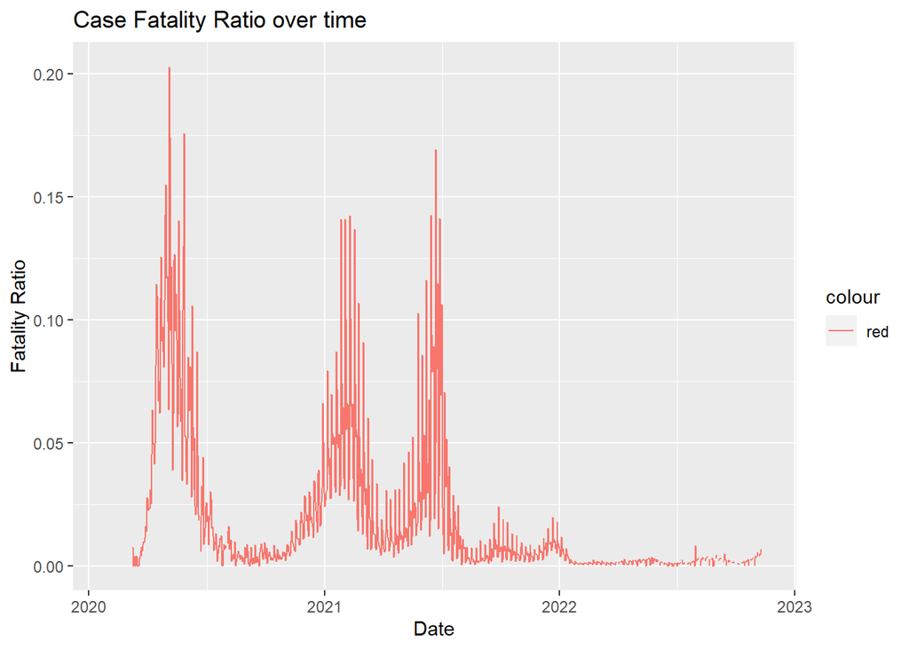

```r
library(ggplot2)
ger_cases<- read.csv(file = "C:/Users/s.zamani/Desktop/R programming/ger_cases.csv")
ger_deaths<- read.csv(file = "C:/Users/s.zamani/Desktop/R programming/ger_deaths.csv")

merged_file1 <- full_join(ger_cases %>% mutate(date = as.Date(date, format = "%Y-%m-%d")),ger_deaths %>% mutate(date = as.Date(date, format = "%Y-%m-%d")),by = "date")
number_of_rows<-count(merged_file1,date)
merged_file2<-mutate(merged_file1,case_fatality_ratio=new_deaths_per_million/new_cases_per_million)

merged_file2$date <- as.Date(merged_file2$date, format = "%Y-%m-%d")
ggplot(merged_file2, aes(x = date, y = case_fatality_ratio,color="red")) + geom_line() +labs(title = "Case Fatality Ratio over time",x= "Date",y="Fatality Ratio")
```

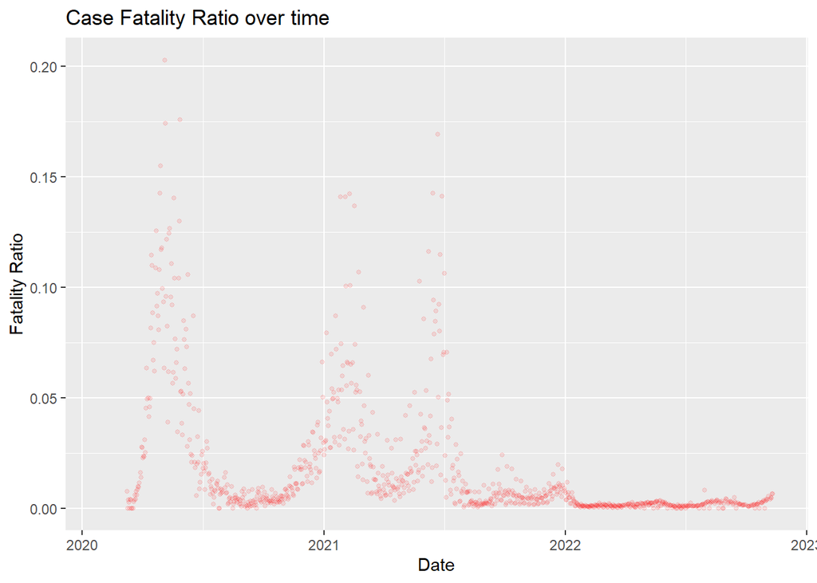

```r
ggplot(data = merged_file2)+ geom_point(mapping = aes(x=date,y=case_fatality_ratio),size=1,alpha=0.1,color="red")+labs(title = "Case Fatality Ratio over time",x= "Date",y="Fatality Ratio")
```